# Лабораторная работа №6

Адресация IPv4 и IPv6. Настройка маршрутизации по протоколу RIP

Цыкунова Екатерина Михайловна

1132246732@rudn.ru

Российский университет дружбы народов

2026-11-05

# Цели и задачи работы

## Цель лабораторной работы

Изучение принципов динамической маршрутизации по протоколам RIPv2 и RIPng в сетях IPv4 и IPv6, настройка маршрутизаторов FRRouting и исследование изменения маршрутов при нарушении сетевых соединений в среде GNS3.

## Задачи лабораторной работы

- создать топологию сети в GNS3 с использованием маршрутизаторов FRRouting и оконечных устройств VPCS;
- настроить IPv4- и IPv6-адресацию на сетевых интерфейсах;
- настроить динамическую маршрутизацию по протоколам RIPv2 и RIPng;
- проверить таблицы маршрутизации, метрики и доступность удалённых сетей;
- исследовать изменение маршрутов при отключении сетевого интерфейса;

# Создание топологии и настройка адресации

## Создаю топологию сети в GNS3

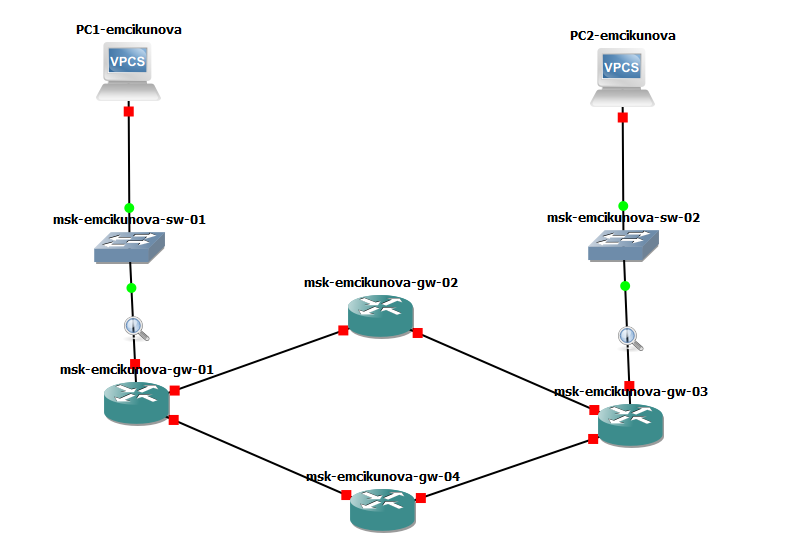

Топология сети с четырьмя маршрутизаторами FRRouting, двумя коммутаторами и оконечными устройствами

## Настраиваю IPv4-адресацию маршрутизаторов

[figure not shown]

Назначение IPv4-адресов интерфейсам маршрутизатора gw-01

## Настраиваю IPv6-адресацию и пересылку пакетов

[figure not shown]

Включение IPv6 forwarding и назначение IPv6-адресов на маршрутизаторе gw-01

# Настройка динамической маршрутизации RIPv2

## Включаю протокол RIPv2 на маршрутизаторах

[figure not shown]

Настройка RIPv2 и добавление интерфейсов в процесс маршрутизации

## Проверяю таблицы маршрутизации и метрики RIPv2

[figure not shown]

Просмотр маршрутов RIP, следующих переходов и метрик на маршрутизаторе gw-01

## Проверяю IPv4-соединение и путь прохождения пакетов

[figure not shown]

Проверка доступности PC2 с помощью ping и трассировка маршрута через gw-02

# Исследование изменения маршрутов RIPv2

## Отключаю интерфейс маршрутизатора gw-02

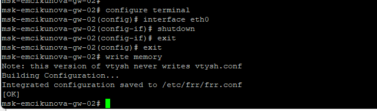

Отключение интерфейса eth0 командой shutdown для моделирования отказа соединения

## Проверяю переключение на альтернативный IPv4-маршрут

[figure not shown]

Проверка доступности PC2 и трассировка нового маршрута через gw-04

# Анализ RIPv2 в Wireshark

## Анализирую служебные сообщения RIPv2

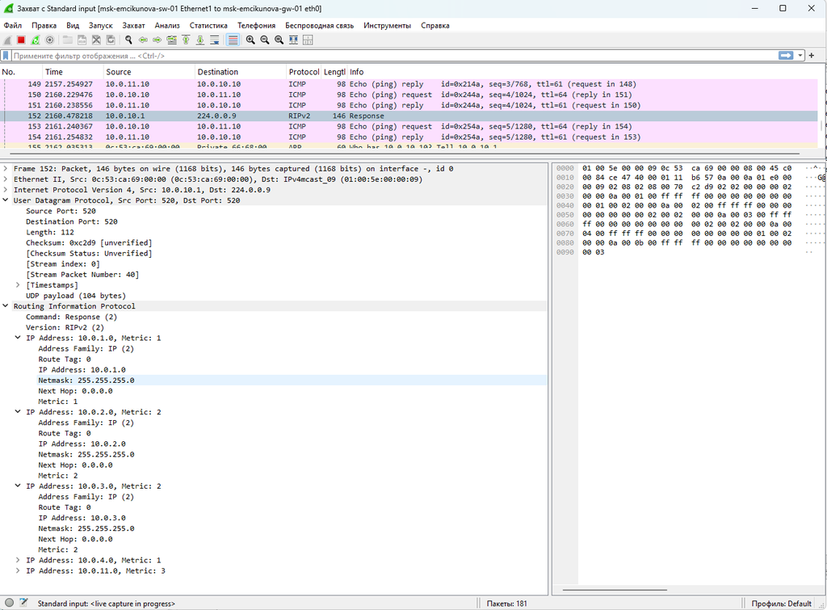

Анализ пакета RIPv2 Response, маршрутных записей и метрик в Wireshark

# Настройка динамической маршрутизации RIPng

## Включаю протокол RIPng на маршрутизаторах

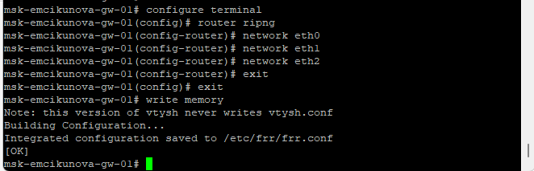

Настройка RIPng и включение IPv6-интерфейсов в процесс маршрутизации

## Проверяю IPv6-соединение и маршрут передачи пакетов

[figure not shown]

Проверка доступности PC2 по IPv6 и трассировка маршрута через gw-02

# Исследование изменения маршрутов RIPng

## Проверяю изменение таблицы RIPng при отказе соединения

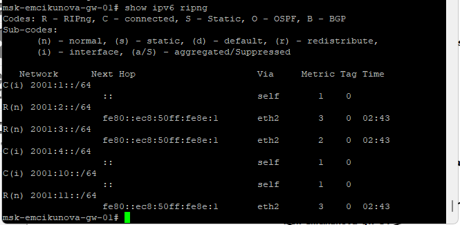

Изменение IPv6-маршрутов и следующего перехода после отключения интерфейса gw-02

## Проверяю альтернативный маршрут IPv6

[figure not shown]

Проверка доступности PC2 и трассировка IPv6-маршрута через gw-04

# Анализ RIPng в Wireshark

## Анализирую служебные пакеты RIPng

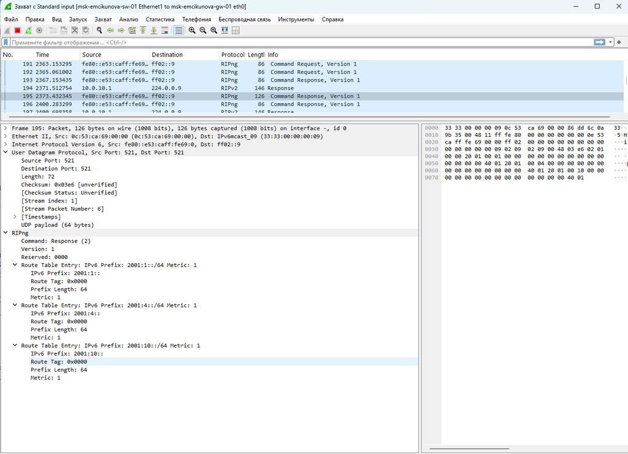

Анализ сообщения RIPng Response, IPv6-префиксов и метрик в Wireshark

# Самостоятельное задание

## Создаю дополнительную топологию сети

[figure not shown]

Топология самостоятельного задания с четырьмя маршрутизаторами и альтернативными маршрутами

## Проверяю соединения между PC1 и PC2 по IPv4 и IPv6

[figure not shown]

Проверка доступности удалённого компьютера и трассировка маршрутов IPv4 и IPv6

## Проверяю таблицы маршрутизации RIPv2 и RIPng

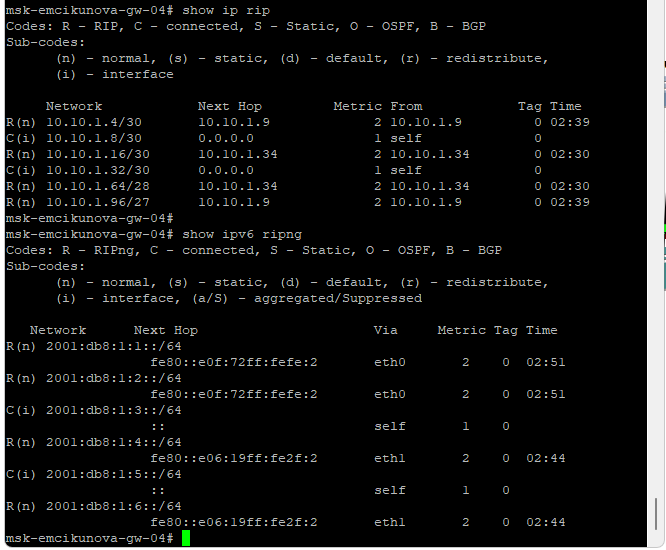

Проверка IPv4- и IPv6-маршрутов, следующих переходов и метрик на маршрутизаторе gw-04

# Вывод

## Результаты лабораторной работы

В GNS3 создана и настроена сеть с четырьмя маршрутизаторами FRRouting, коммутаторами Ethernet и оконечными устройствами VPCS. Настроена адресация IPv4 и IPv6, а также динамическая маршрутизация по протоколам RIPv2 и RIPng.

С помощью команд `show ip route rip`, `show ip rip`, `show ip rip status` и `show ipv6 ripng` проверены таблицы маршрутизации, метрики и источники маршрутной информации. Командами `ping` и `trace` подтверждены доступность удалённых сетей и корректность прохождения пакетов.

При отключении интерфейса маршрутизатора исследовано автоматическое переключение на альтернативный маршрут. В Wireshark проанализированы служебные сообщения RIPv2 и RIPng, содержащие сетевые префиксы и метрики.

В самостоятельной части работы настроена дополнительная сеть с двойным стеком IPv4 и IPv6. Проверены соединения между оконечными устройствами и таблицы маршрутизации, что подтвердило работоспособность протоколов RIPv2 и RIPng.